# Tutorial 5: The Wisdom and Madness of Crowds (Interactive Notebook)

When groups are smarter than individuals — and when they are not

## How to use this notebook

Open `ScienceHighSchool.Rproj` first. Run each code block with the green **Run** button, or place your cursor in the code and press **Cmd/Ctrl + Enter**.

Change one small thing at a time. Then run the block again and look at the result.

## Word list（単語リスト）

| English | 日本語 | Meaning |
| --- | --- | --- |
| wisdom of crowds | 集団の知恵 | groups being more accurate than individuals |
| herding | 群れ行動・付和雷同 | everyone following everyone, ignoring evidence |
| collective behaviour | 集団行動 | patterns produced by many interacting individuals |
| environment change | 環境変化 | when the best option stops being the best |
| trade-off | トレードオフ | improving one thing makes another worse |

## Part 1: The wisdom of crowds

In 1906, the scientist Francis Galton visited a country fair where about 800 people guessed the weight of an ox. Almost nobody was right. But the **average of all guesses** missed the true weight by less than 1%.

Why does this work? Let’s simulate it. Say the true answer is 500 (beans in a jar, weight of an ox, whatever). Each person’s guess is noisy — sometimes too high, sometimes too low:

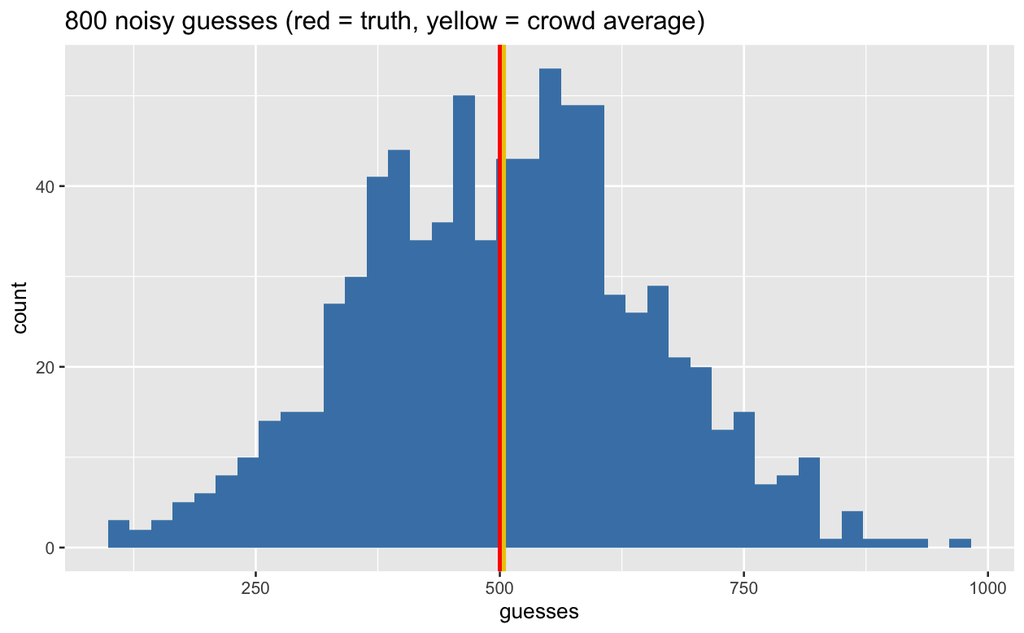

```r
library(ggplot2)
set.seed(2026)

truth <- 500
guesses <- rnorm(800, mean = truth, sd = 150)  # 800 noisy guesses

ggplot(data.frame(guesses), aes(guesses)) +
  geom_histogram(bins = 40, fill = "steelblue") +
  geom_vline(xintercept = truth, color = "red", linewidth = 1) +
  geom_vline(xintercept = mean(guesses), color = "gold2", linewidth = 1) +
  labs(title = "800 noisy guesses (red = truth, yellow = crowd average)")
```

Individual errors are huge, but they point in *different directions* — so when we average, they **cancel out**. How big must a crowd be?

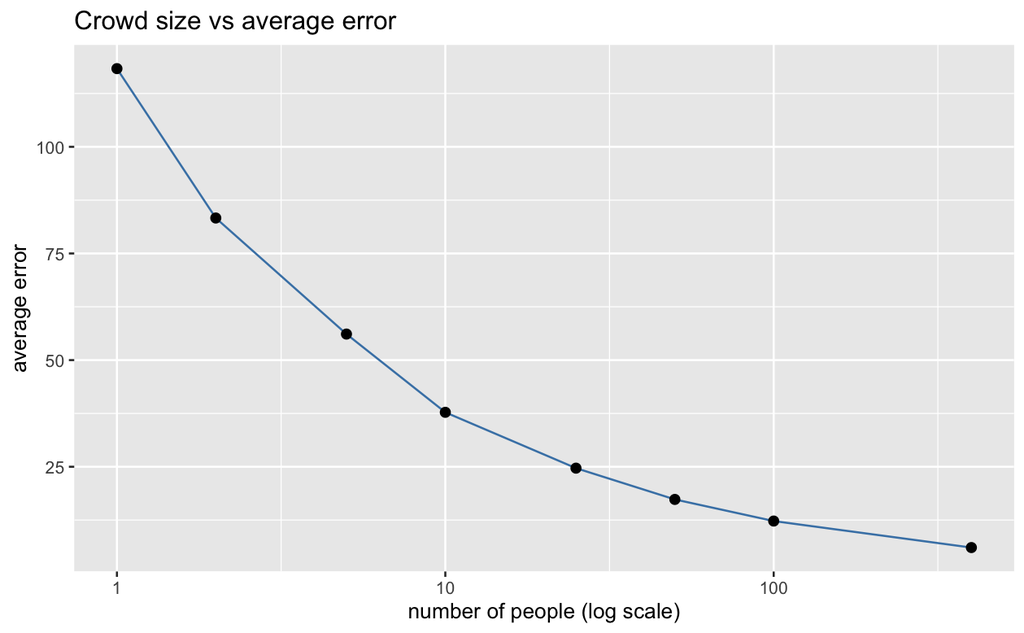

```r
crowd_error <- function(n_people) {
  mean(replicate(1000, abs(mean(rnorm(n_people, truth, sd = 150)) - truth)))
}
sizes <- c(1, 2, 5, 10, 25, 50, 100, 400)
errors <- sapply(sizes, crowd_error)

ggplot(data.frame(sizes, errors), aes(sizes, errors)) +
  geom_line(color = "steelblue") + geom_point(size = 2) +
  labs(title = "Crowd size vs average error",
       x = "number of people (log scale)", y = "average error") +
  scale_x_log10()
```

## Try it! — break the wisdom

The magic needs errors that cancel out.

Can you make everyone share a bias? How does this affect the result? Does the number of people change it?

How wrong is the crowd average now? Can more people fix a shared bias?

Write down your guess before you run the code.

**Click here for a hint**

If we multiply the average we sample from with a factor, we can affect the mean guessed value. Here, people would systematically underestimate the true value. `guesses <- rnorm(800, mean = truth * 0.7, sd = 150)`

**ネタバレ注意! Click after you have tested yourself.**

*This is why copying can be dangerous: it makes people’s errors similar.* *But similar errors do not cancel out when averaging!*

## Part 2: When the world changes

In Tutorial 4, our copying societies looked smart. But we tested them in a **stable world**, where the best option stays best forever. Real worlds change: shops close, trends die, environments shift.

The machines begin with reward probabilities 0.50 for A and 0.70 for B. At `change_point = 76`, they secretly **swap**, so A becomes better. Nobody is told.

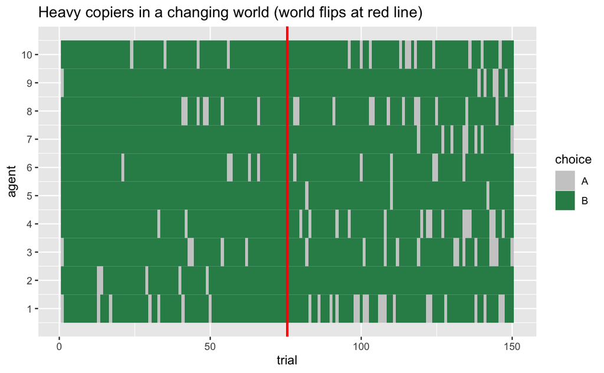

```r
source(paste0(project_root,'/R/bandit_functions.R'))
set.seed(2026)

sim <- simulate_group(n_agents = 10, n_trials = 150,
                      reward_probs = c(0.5, 0.7),
                      sigma = 0.7, theta = 4,     # strong social influence
                      alpha = 0.7, beta = 5,
                      change_point = 76)

ggplot(sim, aes(trial, agent, fill = factor(choice))) +
  geom_tile() +
  geom_vline(xintercept = 75.5, color = "red", linewidth = 1) +
  scale_fill_manual(values = c("1" = "grey80", "2" = "seagreen"),
                    name = "choice", labels = c("A", "B")) +
  scale_y_continuous(breaks = 1:10) +
  labs(title = "Heavy copiers in a changing world (world flips at red line)")
```

This example combines a fast learning rate ($\alpha = 0.7$), much social learning ($\sigma = 0.7$), and strong conformity ($\theta = 4$). The group can coordinate quickly, but it can also become rigid.

What happens after the environment changes?

**ネタバレ注意! Click after you have tested yourself.**

Even after the environment changes, the group often **keeps choosing the old option** — everyone copies everyone, and the majority keeps making itself bigger. This is **herding**.

## Part 3: The full picture

Let’s measure this properly: for several values of $\sigma$, average many simulations, in a world that flips halfway.

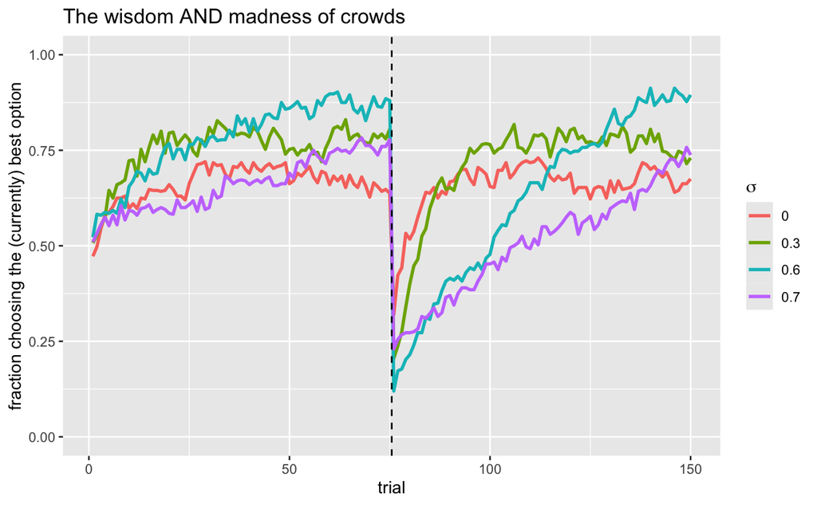

```r
sweep <- do.call(rbind, lapply(c(0, 0.3, 0.6, 0.7), function(s) {
  perf <- average_performance(n_reps = 40, n_agents = 10, n_trials = 150,
                              reward_probs = c(0.5, 0.7),
                              alpha = 0.7, beta = 5,
                              sigma = s, theta = 4, change_point = 76)
  transform(perf, sigma = s)
}))

ggplot(sweep, aes(trial, correct, color = factor(sigma))) +
  geom_line(linewidth = 1) +
  geom_vline(xintercept = 75.5, linetype = "dashed") +
  ylim(0, 1) +
  labs(title = "The wisdom AND madness of crowds",
       y = "fraction choosing the (currently) best option",
       color = expression(sigma))
```

How would you interpret these results? Let’s test ourselves before revealing the summary!

**ネタバレ注意! Click after you have tested yourself.**

In this experiment, only $\sigma$ changes. We hold $\alpha = 0.7$, $\beta = 5$, and $\theta = 4$ constant. The best strategy depends on both the environment and when we measure success. This change from many individual choices to a group-level pattern is **collective behaviour**.

## The big idea

Researchers at the University of St Andrews have tested exactly this with real people playing bandit games in groups online — and found the same pattern: conformist copying produces both collective wisdom and, in changing environments, herding. See Toyokawa, Whalen & Laland (2019), *Nature Human Behaviour*.

## Try it! — questions worth investigating

Each of these could become part of your **final presentation**: Choose one (or more!), then write your prediction before changing the code.

1. **Best strategy in a restless world**: make the world flip every 50 trials (`change_point` currently supports one flip — can you modify `simulate_group()` for repeated flips? Ask us for hints!). What $\sigma$ wins now?
2. **Group size**: is herding worse in bigger groups? Try `n_agents = 5, 20, 50` with $\sigma = 0.6$.
3. **Conformity strength**: fix $\sigma = 0.5$ and sweep `theta = 1, 2, 4`. Is strong conformity ever good?
4. **Individual differences**: give agents different $\alpha$, $\beta$, $\sigma$, or $\theta$ values. What happens if two agents are strong conformists while the others balance individual and social learning? See the optional appendix in Tutorial 4 for starter code.

## Part 4: From models to real behaviour — you are the data

Models are only half of human science. The other half: **data from real people**. The good news is, we have four real people attending this camp!

The game has three machines and 40 turns. Each machine has a hidden chance of paying one coin. Your goal is to earn as many coins as possible.

### How to play

1. Open `ScienceHighSchool.Rproj` in RStudio.
2. Load the game in the **Console**:

```r
source("R/play_bandit_game.R")
```

3. Everyone plays once without social information. Use a short nickname:

```r
play_game("YourName")
```

4. Type `1`, `2`, or `3` on each turn, then press **Enter**. R tells you whether you won a coin and shows your total score.
5. After everyone finishes the solo game, play again with hints:

```r
play_game("YourName", hints = TRUE)
```

### What does a hint mean?

A hint comes from **saved human games**, not simulated agents. On turn 12, for example, the program looks at turn 12 in all CSV files already stored in `data/game_records/`. It shows how many games chose each machine. It does not show other players’ rewards or the true reward probabilities.

The hint pool is loaded when your game starts. By default, it includes every saved solo and social game. This means that play order matters. It also means that test records should be removed before the real social games begin.

### Where is your data stored?

Each game creates one CSV file in `data/game_records/`, such as `YourName_solo.csv` or `YourName_social.csv`. Each row stores the player, mode, trial, choice, reward, and social counts (`hint_1`, `hint_2`, and `hint_3`). Replaying with the same nickname and mode replaces the old file.

These files may contain names. Keep them local. Do not upload or commit them.

To inspect the filenames, run:

```r
list_game_records()
```

To delete an exact test record, use the same nickname and mode:

```r
delete_game_record("Test", hints = FALSE) # delete Test_solo.csv
delete_game_record("Test", hints = TRUE)  # delete Test_social.csv
```

Deletion cannot be undone. Check the filename first, and do not delete another student’s record.

### Analyse the group

After everyone finishes, compare your learning curve with the model’s:

```r
files <- list.files(paste0(project_root,"/data/game_records"), pattern = "\\.csv$", full.names = TRUE)
keep <- c("player", "mode", "trial", "choice", "reward")
human <- do.call(rbind, lapply(files, function(f) read.csv(f)[keep]))

# machine 2 pays best (0.65) - how often did humans find it?
human_curve <- aggregate(found_best ~ trial + mode,
                         data = transform(human, found_best = as.numeric(choice == 2)),
                         FUN = mean)
ggplot(human_curve, aes(trial, found_best, color = mode)) +
  geom_hline(yintercept = 1 / 3, linetype = "dotted") +
  geom_line(linewidth = 1) + ylim(0, 1) +
  scale_color_manual(values = c(solo = "steelblue", social = "darkorange")) +
  labs(title = "Did WE find the best machine?", y = "fraction choosing machine 2",
       color = "session")
```

Questions you can now investigate like a real cognitive scientist:

- Do humans learn faster or slower than the model? What $\alpha$ and $\beta$ make the model *most human-like*?
- Did players with social hints do better than solo players?
- Did anyone show conformity — following hints even after bad experiences?

## Optional final activity: play together in real time

The console game above uses choices saved from earlier games. The COSMOS multiplayer task lets everyone play **at the same time** (real-time, リアルタイム). It is a 16-choice fishing game: click or tap one square of a 4 × 4 ocean grid on each turn and try to catch as many fish as possible.

1. Ask the instructor to choose a condition, then open the same link together:
   - [Individual condition — play without social information](http://tk2-127-63496.vs.sakura.ne.jp:8989/)
   - [Social condition — play with the group](http://tk2-127-63496.vs.sakura.ne.jp:8989/?condition=group)
2. In the social condition, open the link at roughly the same time as the other players. Everyone who enters within the 30-second waiting window joins the same session.
3. In the social condition, you can see other players’ **choices**, but not their rewards. Start together and notice whether the group spreads out or forms a herd.
4. At the end, download the session results. The social-condition download also contains social information.

For screenshots and the original activity notes, see the [COSMOS instructions](https://cosmossummerschool.github.io/notebooks/tutorial-1-n-armed-task.html). The game needs an internet connection and uses an `http` link, so do not enter personal information.

Keep downloaded results local. A safe place in this project is a new `data/game_records/realtime/` folder; Git ignores everything inside `data/game_records/`. Do not mix these files with the local console-game CSVs one folder above, because their columns may be different.

Possible presentation questions:

- Did the group discover the best fishing spot faster in the social condition?
- Did players converge on one spot? Was it actually a good spot?
- How did one player’s choices change after seeing the group?
- What extra columns in the social download could measure conformity (多数派同調傾向)?

## What you learned

- Independent errors cancel: crowds can be wiser than any individual
- Copying makes errors *dependent* — dependent errors can no longer cancel out.
- The same strategy can be smart or disastrous depending on the environment
- Models become science when compared with real behaviour — including yours

**Now: pick any questions, modify or write code, run simulations, make figures, and build your presentation.** See `project/mini_project_menu.md`.